# Boarding Time

Analysts: Kaitlin Olson and Nichole Carlson Investigators: Freddi Tran and Sean Michael Report generated: 03/16/2020

# 1 Introduction

Our goal in this project is to explore the relationship between race/ethnicity, gender and age (as primary predictors), and boarding time. Before any analysis, preliminary data exploration was completed.

# 2 Methods

I combined race and ethnicity to be one variable. I collapsed the age variable into different age ranges. Additionally, I collapsed the primary care provider, insurance, and primary language variables to binary variables. I classified “NULL” and “ASKED, NO PCP” as having no primary care provider, “NULL” for no insurance and then split the language variable into english speaking and non-english speaking.

I created several tables, showing relationships between each of the primary predictors and the other variables in this dataset. I also created box and whisker plots to show the relationship between the primary predictors and boarding time.

# 3 Results

In general, the plots created show extreme skew of the response variable, boarding time. This suggests that we would need to transform this variable.

For variables that I collapsed, if there are alternative ways to collapse these variables that you would prefer, please let me know. This would be most important for the race/ethnicity variable. The way that I have combined them creates a very large variable, with several columns. Response on how to create this variable is needed, or we can leave them separate and do two separate analyses for race and ethnicity. Additionally, there are several variables that have very low counts for certain levels within the variable. Suggestions for how to collapse all variables are needed.

## 3.1 Descriptitve Statistics

### 3.1.1 MYD

Something I noticed here was that the year 2013 has much higher averages for boarding time. Is there something that happened this year that would account for this?

Relationship between date and boarding time

| Date | Average | Median | SD | Min | Max | N |
| --- | --- | --- | --- | --- | --- | --- |
| 01/2013 | 826.51740 | 353.0 | 1046 | 0 | 5745 | 862 |
| 01/2014 | 133.75305 | 78.0 | 204 | 0 | 3327 | 3033 |
| 01/2015 | 140.81847 | 89.0 | 183 | 0 | 2656 | 3531 |
| 01/2016 | 130.08888 | 93.0 | 136 | 0 | 1609 | 3409 |
| 01/2017 | 142.01055 | 97.0 | 153 | 0 | 1317 | 3695 |
| 01/2018 | 147.73572 | 104.0 | 154 | 0 | 1558 | 3799 |
| 01/2019 | 196.68784 | 116.0 | 237 | 0 | 2180 | 3809 |
| 02/2013 | 888.13032 | 515.0 | 1014 | 0 | 6566 | 775 |
| 02/2014 | 105.98589 | 76.0 | 134 | 0 | 2557 | 2623 |
| 02/2015 | 116.92539 | 82.0 | 143 | 0 | 1729 | 3056 |
| 02/2016 | 120.90688 | 93.0 | 113 | 0 | 1964 | 3286 |
| 02/2017 | 151.09049 | 104.0 | 160 | 0 | 1487 | 3260 |
| 02/2018 | 133.19639 | 97.0 | 136 | 0 | 2330 | 3213 |
| 02/2019 | 201.46025 | 125.0 | 243 | 0 | 4852 | 3409 |
| 03/2013 | 670.22454 | 263.5 | 809 | 0 | 4548 | 864 |
| 03/2014 | 101.63792 | 77.0 | 99 | 0 | 1333 | 2922 |
| 03/2015 | 131.59114 | 88.0 | 162 | 0 | 2022 | 3588 |
| 03/2016 | 128.06372 | 91.0 | 127 | 0 | 1272 | 3625 |
| 03/2017 | 125.19781 | 96.0 | 115 | 0 | 1266 | 3468 |
| 03/2018 | 129.37633 | 96.0 | 147 | 0 | 2410 | 3566 |
| 03/2019 | 178.17868 | 111.0 | 215 | 0 | 2423 | 3789 |
| 04/2013 | 273.58645 | 129.0 | 428 | 0 | 3141 | 856 |
| 04/2014 | 88.16152 | 72.0 | 66 | 0 | 813 | 2848 |
| 04/2015 | 113.29906 | 86.0 | 101 | 0 | 1273 | 3414 |
| 04/2016 | 112.39074 | 85.0 | 110 | 0 | 1405 | 3391 |
| 04/2017 | 116.04376 | 93.0 | 91 | 0 | 1210 | 3336 |
| 04/2018 | 151.26469 | 100.0 | 190 | 0 | 4541 | 3438 |
| 04/2019 | 176.02138 | 109.0 | 215 | 0 | 2383 | 3461 |
| 05/2013 | 315.03976 | 149.0 | 421 | 0 | 3822 | 1006 |
| 05/2014 | 94.50595 | 75.0 | 144 | 0 | 6764 | 2943 |
| 05/2015 | 129.29748 | 88.0 | 141 | 0 | 1675 | 3496 |
| 05/2016 | 100.48414 | 83.0 | 77 | 0 | 905 | 3437 |
| 05/2017 | 116.84711 | 90.0 | 111 | 0 | 1386 | 3375 |
| 05/2018 | 134.40544 | 95.0 | 145 | 0 | 1773 | 3712 |
| 05/2019 | 149.84620 | 101.0 | 170 | 0 | 2224 | 3602 |
| 06/2013 | 113.00520 | 96.0 | 79 | 0 | 604 | 961 |
| 06/2014 | 99.19778 | 74.0 | 111 | 0 | 3082 | 2796 |
| 06/2015 | 117.09988 | 87.0 | 109 | 0 | 1556 | 3304 |
| 06/2016 | 97.93232 | 84.0 | 67 | 0 | 874 | 3295 |
| 06/2017 | 107.83211 | 88.0 | 80 | 0 | 884 | 3264 |
| 06/2018 | 134.01891 | 94.0 | 203 | 0 | 5356 | 3490 |
| 06/2019 | 137.23971 | 99.0 | 146 | 0 | 2419 | 3354 |
| 07/2013 | 111.65855 | 78.0 | 140 | 0 | 1654 | 1725 |
| 07/2014 | 93.08620 | 75.0 | 69 | 0 | 792 | 2935 |
| 07/2015 | 120.13728 | 86.0 | 137 | 0 | 3744 | 3482 |
| 07/2016 | 116.97321 | 90.5 | 97 | 0 | 845 | 3472 |
| 07/2017 | 107.29960 | 86.0 | 86 | 0 | 1451 | 3271 |
| 07/2018 | 152.85371 | 101.0 | 178 | 0 | 1714 | 3664 |
| 07/2019 | 142.72928 | 96.0 | 172 | 0 | 2447 | 3583 |
| 08/2013 | 107.76379 | 73.0 | 137 | 0 | 3073 | 2121 |
| 08/2014 | 97.78872 | 77.0 | 79 | 0 | 1205 | 3086 |
| 08/2015 | 138.35647 | 90.0 | 165 | 0 | 1883 | 3529 |
| 08/2016 | 107.25956 | 87.0 | 82 | 0 | 1627 | 3348 |
| 08/2017 | 115.05609 | 92.0 | 97 | 0 | 1082 | 3423 |
| 08/2018 | 149.65585 | 101.0 | 173 | 0 | 2487 | 3513 |
| 09/2013 | 108.06546 | 71.0 | 151 | 0 | 2089 | 1940 |
| 09/2014 | 98.64712 | 74.0 | 94 | 0 | 1383 | 3001 |
| 09/2015 | 122.74262 | 88.0 | 130 | 0 | 1391 | 3322 |
| 09/2016 | 118.45573 | 92.0 | 103 | 0 | 1261 | 3298 |
| 09/2017 | 131.05969 | 93.0 | 138 | 0 | 1486 | 3267 |
| 09/2018 | 162.33784 | 101.0 | 209 | 0 | 3865 | 3404 |
| 10/2013 | 85.45335 | 67.0 | 81 | 0 | 1291 | 1908 |
| 10/2014 | 91.46568 | 76.0 | 65 | 0 | 1052 | 3030 |
| 10/2015 | 108.00494 | 84.0 | 97 | 0 | 1170 | 3444 |
| 10/2016 | 114.18857 | 90.0 | 92 | 0 | 1227 | 3341 |
| 10/2017 | 125.28718 | 94.0 | 126 | 0 | 1528 | 3402 |
| 10/2018 | 126.67425 | 95.0 | 125 | 0 | 1378 | 3472 |
| 11/2013 | 118.85136 | 74.0 | 181 | 0 | 2095 | 2718 |
| 11/2014 | 87.89922 | 74.0 | 59 | 0 | 721 | 3086 |
| 11/2015 | 106.42595 | 83.0 | 95 | 0 | 1724 | 3275 |
| 11/2016 | 112.55837 | 88.0 | 96 | 0 | 1661 | 3238 |
| 11/2017 | 135.72984 | 97.0 | 141 | 0 | 1388 | 3398 |
| 11/2018 | 132.37533 | 93.0 | 161 | 0 | 2886 | 3453 |
| 12/2013 | 101.28585 | 75.0 | 117 | 0 | 2561 | 3054 |
| 12/2014 | 113.08182 | 84.0 | 112 | 0 | 1486 | 3569 |
| 12/2015 | 127.23614 | 89.0 | 130 | 0 | 1397 | 3409 |
| 12/2016 | 127.30464 | 94.0 | 130 | 0 | 1689 | 3555 |
| 12/2017 | 126.23096 | 97.0 | 119 | 0 | 1233 | 3611 |
| 12/2018 | 147.16843 | 100.0 | 216 | 0 | 8607 | 3788 |

### 3.1.2 Age

The age range in this data set is 18-90. The mean, at 58.73 and the median, 60, are very similar. There are only 7 missing data points. The mean and median boarding times increase until the 50-59 age range and decrease.

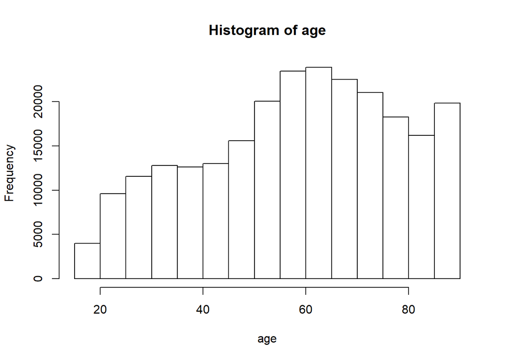

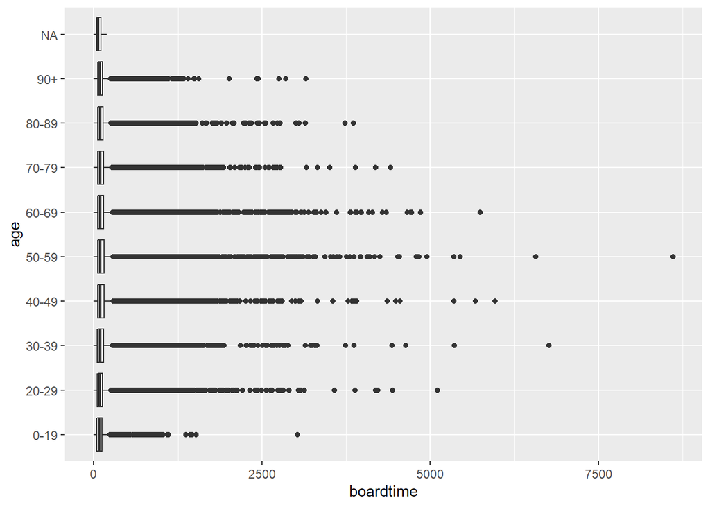

Relationship between age and boarding time

| Age (years) | Average | Median | SD | Min | Max | N |
| --- | --- | --- | --- | --- | --- | --- |
| 0-19 | 106.98387 | 76 | 149 | 0 | 3023 | 2418 |
| 20-29 | 122.30697 | 80 | 191 | 0 | 5109 | 20308 |
| 30-39 | 133.16492 | 88 | 192 | 0 | 6764 | 25346 |
| 40-49 | 141.75994 | 91 | 210 | 0 | 5961 | 27822 |
| 50-59 | 143.26399 | 93 | 220 | 0 | 8607 | 41847 |
| 60-69 | 139.26537 | 92 | 198 | 0 | 5745 | 47036 |
| 70-79 | 131.18241 | 91 | 162 | 0 | 4410 | 40185 |
| 80-89 | 125.75091 | 89 | 150 | 0 | 3855 | 29828 |
| 90+ | 117.34870 | 85 | 132 | 0 | 3149 | 9699 |
| NA | 79.71429 | 59 | 64 | 0 | 196 | 7 |

### 3.1.3 Gender

The distribution of male and female patients is nearly equal. There are only 8 responses labeled “unknown.” The mean and median are very similar for each gender, which females having slightly shorter boarding times.

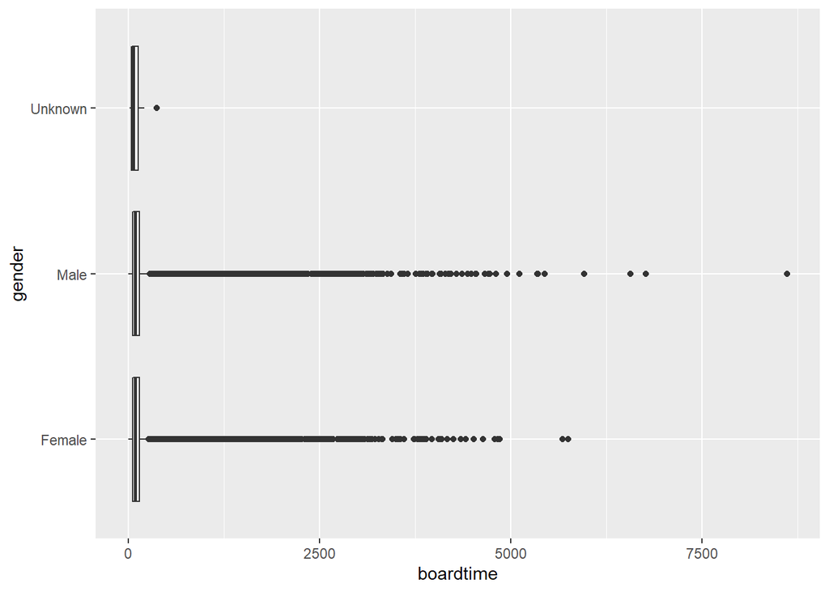

Relationship between gender and boarding time

| Gender | Average | Median | SD | Min | Max | N |
| --- | --- | --- | --- | --- | --- | --- |
| Female | 132.1158 | 89.0 | 183 | 0 | 5745 | 122357 |
| Male | 135.9391 | 90.0 | 195 | 0 | 8607 | 122131 |
| Unknown | 113.2500 | 61.5 | 121 | 17 | 372 | 8 |

### 3.1.4 Race

There is a large proportion of individuals in this dataset that identify as White/Caucasian, followed by “other” and then Black/African American. Black/African American individuals have the largest mean and median values for boarding time while “unspecified” individuals have the lowest boarding times. How should the *unspecified, unknown, and patient refused be combined?

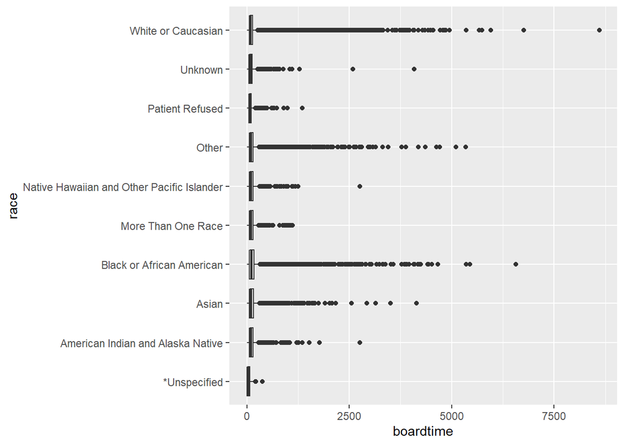

Relationship between race and boarding time

| Race | Average | Median | SD | Min | Max | N |
| --- | --- | --- | --- | --- | --- | --- |
| *Unspecified | 62.34043 | 43 | 77 | 0 | 383 | 47 |
| American Indian and Alaska Native | 136.09697 | 92 | 170 | 0 | 2759 | 1320 |
| Asian | 149.19896 | 97 | 208 | 0 | 4141 | 4609 |
| Black or African American | 164.72286 | 104 | 253 | 0 | 6566 | 26225 |
| More Than One Race | 141.33940 | 94 | 161 | 0 | 1121 | 604 |
| Native Hawaiian and Other Pacific Islander | 140.37386 | 91 | 190 | 0 | 2765 | 658 |
| Other | 144.17609 | 95 | 206 | 0 | 5349 | 26287 |
| Patient Refused | 96.37539 | 74 | 99 | 0 | 1359 | 967 |
| Unknown | 113.18314 | 82 | 165 | 0 | 4090 | 1649 |
| White or Caucasian | 128.10059 | 87 | 175 | 0 | 8607 | 182130 |

### 3.1.5 Ethnicity

32652 individuals identify as Hispanic. Hispanic individuals have slightly higher means and medians for boarding times than patients that identify as Non-Hispanic. How should *unspecified, unknown and patient refused be combined?

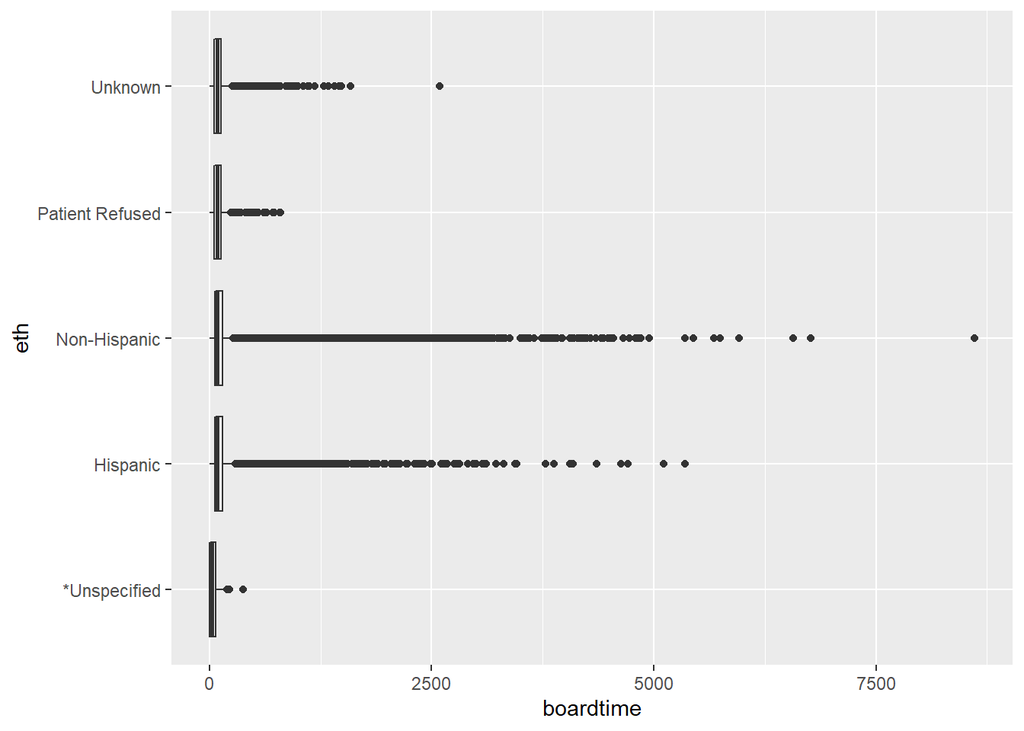

Relationship between ethnicity and boarding time

| Ethnicity | Average | Median | SD | Min | Max | N |
| --- | --- | --- | --- | --- | --- | --- |
| *Unspecified | 58.39583 | 32 | 78 | 0 | 383 | 48 |
| Hispanic | 138.59819 | 91 | 200 | 0 | 5349 | 32652 |
| Non-Hispanic | 133.57895 | 90 | 188 | 0 | 8607 | 208846 |
| Patient Refused | 112.20297 | 86 | 109 | 0 | 803 | 606 |
| Unknown | 117.25427 | 85 | 150 | 0 | 2594 | 2344 |

### 3.1.6 Combining race and ethnicity

Please let me know how you would like this variable to be constructed, if different than below.

Relationship between race/ethnicity and boarding time

| Race/Ethnicity | Average | Median | SD | Min | Max | N |
| --- | --- | --- | --- | --- | --- | --- |
| Hispanic American Indian and Alaska Native | 117.2651 | 86.0 | 146 | 0 | 1773 | 249 |
| Hispanic and More Than One Race | 137.9172 | 92.5 | 161 | 0 | 1074 | 290 |
| Hispanic and Other Race | 144.5966 | 95.0 | 208 | 0 | 5349 | 22606 |
| Hispanic Asian | 110.9412 | 88.0 | 100 | 0 | 520 | 34 |
| Hispanic Black or African American | 156.6359 | 107.0 | 185 | 0 | 2073 | 217 |
| Hispanic Native Hawaiian or Other Pacific Islander | 126.9836 | 91.0 | 98 | 0 | 572 | 61 |
| Hispanic White or Caucasian | 125.9596 | 82.0 | 182 | 0 | 4061 | 8462 |
| Hispanic with Unknown Race | 127.6958 | 92.0 | 235 | 0 | 4090 | 378 |
| Non-Hispanic American Indian and Alaska Native | 140.3843 | 93.0 | 175 | 0 | 2759 | 1067 |
| Non-Hispanic and More Than One Race | 143.6225 | 96.0 | 160 | 0 | 1121 | 302 |
| Non-Hispanic and Other Race | 141.6922 | 94.0 | 192 | 0 | 4186 | 3665 |
| Non-Hispanic Asain | 149.4779 | 97.0 | 208 | 0 | 4141 | 4574 |
| Non-Hispanic Black or African American | 164.8051 | 104.0 | 253 | 0 | 6566 | 26003 |
| Non-Hispanic Native Hawaiian or Other Pacific Islander | 141.8272 | 91.0 | 198 | 0 | 2765 | 596 |
| Non-Hispanic White or Caucasian | 128.2417 | 87.0 | 175 | 0 | 8607 | 173361 |
| Non-Hispanic with Unknown Race | 103.6640 | 77.0 | 121 | 0 | 2594 | 2631 |

### 3.1.7 Insurance (1) vs. no insurance (0)

Under then assumption that “NULL” is no insurance, there are only ~10,000 individuals that do not have insurance. Individuals that have no insurance have a lower median for boarding times than individuals that do have insurance. Please let me know if the variable should be collapsed differently.

Relationship between insurance and boarding time

| Insurance | Average | Median | SD | Min | Max | N |
| --- | --- | --- | --- | --- | --- | --- |
| 0 | 138.6275 | 87 | 216 | 0 | 6764 | 10193 |
| 1 | 133.8248 | 90 | 188 | 0 | 8607 | 234303 |

### 3.1.8 Arrival

The majority of patients (142,557) were identified as walk-in and then ground EMS (99,277) for arrival. Patients that had a “police” arrival had a higher average and median boarding time than other individuals.

Relationship between mode of arrival and boarding time

| Mode of arrival | Average | Median | SD | Min | Max | N |
| --- | --- | --- | --- | --- | --- | --- |
| *Unspecified | 47.47048 | 11 | 77 | 0 | 640 | 525 |
| Air EMS | 94.79463 | 64 | 143 | 0 | 1972 | 1602 |
| Ground EMS | 134.38675 | 91 | 178 | 0 | 8607 | 99277 |
| Police | 169.73832 | 100 | 278 | 0 | 4541 | 535 |
| Walk in | 134.39869 | 89 | 196 | 0 | 6764 | 142557 |

### 3.1.9 ED clinical disposition

The majority of patients had an IP bed requested (233,799). How should other levels with only a few counts be combined?

Relationship between ED clinical disposition and boarding time

| ED clinical disposition | Average | Median | SD | Min | Max | N |
| --- | --- | --- | --- | --- | --- | --- |
| *Unspecified | 3.47154 | 0 | 39 | 0 | 922 | 738 |
| Admit OR | 5.87500 | 0 | 17 | 0 | 47 | 8 |
| Admit Stepdown/ICU | 0.00000 | 0 | 0 | 0 | 0 | 2 |
| Admit to Floor/TELE | 154.00000 | 154 | NaN | 154 | 154 | 1 |
| AMA | 208.13043 | 97 | 602 | 0 | 5356 | 92 |
| Arrived in Error | 0.00000 | 0 | NaN | 0 | 0 | 1 |
| Discharge | 128.00531 | 51 | 241 | 0 | 1973 | 377 |
| Expired | 225.92000 | 150 | 263 | 0 | 1130 | 25 |
| IP Bed Requested | 136.89330 | 91 | 189 | 0 | 8607 | 233799 |
| Left Before Visit Complete | 106.33333 | 61 | 125 | 0 | 353 | 6 |
| Left Without Being Seen (LWBS) | 70.00000 | 70 | NaN | 70 | 70 | 1 |
| No Charge Visit | 0.00000 | 0 | NaN | 0 | 0 | 1 |
| Observation Status | 133.61290 | 0 | 279 | 0 | 1121 | 31 |
| Send to L&D | 11.35144 | 0 | 32 | 0 | 235 | 313 |
| Sent to Another Hosp Dept (GI Lab, OR, etc) | 5.89948 | 0 | 33 | 0 | 1021 | 2885 |
| Transfer to Another Facility (Discharge) | 159.91506 | 123 | 203 | 0 | 4852 | 4097 |
| Triaged to OB | 3.13922 | 0 | 82 | 0 | 3073 | 2119 |

### 3.1.10 CDU patient flag

Only 10,515 patients had a CDU patient flag. Individuals with the flag had a much higher average and median boarding time than individuals that did not have the flag.

Relationship between CDU patient flag and boarding time

| CDU patient flag | Average | Median | SD | Min | Max | N |
| --- | --- | --- | --- | --- | --- | --- |
| N | 132.1698 | 89 | 189 | 0 | 8607 | 233981 |
| Y | 175.3067 | 119 | 186 | 0 | 3779 | 10515 |

### 3.1.11 Primary care provider (1) vs. no primary care provider (0)

Under then assumption that “NULL” and “ASKED, NOPCP” are the only individuals that did not have a primary care provider, 55,839 individuals identified as not having a primary care provider. Individuals without a primary care provider had a lower median boarding time than individuals that do have a primary care provider. Please let me know if the variable should be collapsed differently.

Relationship between having a primary care provider or not and boarding time

| Primary Care Provider | Average | Median | SD | Min | Max | N |
| --- | --- | --- | --- | --- | --- | --- |
| 0 | 156.023 | 87 | 295 | 0 | 6764 | 55839 |
| 1 | 127.514 | 90 | 143 | 0 | 8607 | 188657 |

### 3.1.12 Marital status

103,686 patients identified as being married. Individuals that were legally separated had the longest average and median boarding time. Please let me know how to collapse the other levels of this variable.

Relationship between marital status and boarding time

| Marital Status | Average | Median | SD | Min | Max | N |
| --- | --- | --- | --- | --- | --- | --- |
| *Unspecified | 104.3979 | 76 | 122 | 0 | 1526 | 2136 |
| Divorced | 138.2107 | 91 | 195 | 0 | 5356 | 24419 |
| Legally Separated | 155.4441 | 99 | 224 | 0 | 4707 | 3772 |
| Married | 129.3087 | 88 | 176 | 0 | 6566 | 103686 |
| Other | 106.5979 | 76 | 129 | 0 | 1099 | 194 |
| Significant Other | 142.0119 | 93 | 202 | 0 | 3865 | 4803 |
| Single | 140.0839 | 92 | 209 | 0 | 8607 | 71224 |
| Unknown | 109.5193 | 81 | 128 | 0 | 1376 | 1425 |
| Widowed | 132.1869 | 91 | 177 | 0 | 4852 | 32837 |

### 3.1.13 Sexual Orientation

Please let me know how to relevel this variable. As the majority of the responses (225,821) to this variable are blank, we should reconsider using it in the analysis.

Relationship between sexual orientation and boarding time

| Sexual Orientation | Average | Median | SD | Min | Max | N |
| --- | --- | --- | --- | --- | --- | --- |
|  | 133.8431 | 90.0 | 191 | 0 | 8607 | 225821 |
| Bisexual | 130.8527 | 88.0 | 151 | 0 | 1016 | 224 |
| Choose not to disclose | 135.3569 | 89.0 | 163 | 0 | 1614 | 538 |
| Don’t know | 126.0178 | 96.0 | 148 | 0 | 1506 | 394 |
| Gay | 170.4546 | 111.5 | 196 | 0 | 1234 | 242 |
| Lesbian | 140.5156 | 92.0 | 181 | 0 | 1453 | 128 |
| Lesbian or Gay | 160.2778 | 105.5 | 191 | 0 | 1262 | 144 |
| Something else | 146.3256 | 103.0 | 141 | 0 | 761 | 43 |
| Straight (not lesbian or gay) | 135.8101 | 91.0 | 168 | 0 | 3523 | 16962 |

### 3.1.14 Primary Language (english (1) vs. not (0))

Relationship between primary language and boarding time

| Primary Language | Average | Median | SD | Min | Max | N |
| --- | --- | --- | --- | --- | --- | --- |
| 0 | 143.555 | 94 | 214 | 0 | 5109 | 14844 |
| 1 | 133.409 | 89 | 187 | 0 | 8607 | 229652 |

### 3.1.15 Numeric variables

As shown below, all of the numeric variables appear to be skewed, with means and medians that are not very similar. The maximum value is always quite large relative to other values.

### 3.1.16 Boarding time interval

We now know that the zeroes in this dataset represent individuals who did not have the disposition “IP bed requested”/did have the disposition “IP bed requested” but did not have boarding time recorded.

```
##  min Q1 median  Q3  max    mean       sd      n missing
##    0 59     90 145 8607 134.025 189.0327 244496       0
```

### 3.1.17 To provider time

```
##  min Q1 median Q3 max     mean       sd      n missing
##    0  3      7 16 355 14.35759 23.63005 244496       0
```

### 3.1.18 Waiting room time

```
##  min Q1 median Q3  max     mean       sd      n missing
##    0  0      0  0 1102 4.245779 23.38629 244496       0
```

### 3.1.19 Total length of stay from door to leaving ED

```
##  min  Q1 median  Q3     max     mean       sd      n missing
##    0 198    274 381 1052981 348.8445 2418.848 244496       0
```

### 3.1.20 Arrival to decision of disposition time

```
##  min  Q1 median  Q3     max     mean       sd      n missing
##    0 109    164 242 1052874 241.4902 2699.739 244496       0
```

## 3.2 Tables

### 3.2.1 Race/Ethnicity not combined

|  | Overall (n=244496) |
| --- | --- |
| Age (years) |  |
| Mean (SD) | 58.7 (19.2) |
| Missing | 7 (0.0%) |
| Gender |  |
| Female | 122357 (50.0%) |
| Male | 122131 (50.0%) |
| Unknown | 8 (0.0%) |
| Race |  |
| Unknown | 2663 (1.1%) |
| American Indian and Alaska Native | 1320 (0.5%) |
| Asian | 4609 (1.9%) |
| Black or African American | 26225 (10.7%) |
| More Than One Race | 604 (0.2%) |
| Native Hawaiian and Other Pacific Islander | 658 (0.3%) |
| Other | 26287 (10.8%) |
| White or Caucasian | 182130 (74.5%) |
| Ethnicity |  |
| Unknown | 2998 (1.2%) |
| Hispanic | 32652 (13.4%) |
| Non-Hispanic | 208846 (85.4%) |
| Arrival mode grouper |  |
| *Unspecified | 525 (0.2%) |
| Air EMS | 1602 (0.7%) |
| Ground EMS | 99277 (40.6%) |
| Police | 535 (0.2%) |
| Walk in | 142557 (58.3%) |
| ED clinical disposition |  |
| *Unspecified | 738 (0.3%) |
| Admit OR | 8 (0.0%) |
| Admit Stepdown/ICU | 2 (0.0%) |

[output cut: 56 more lines]

### 3.2.2 Stratified by Race/Ethnicity

[output not shown]

### 3.2.3 Race/Ethnicity Combined

As shown, the combination of race and ethnicity produces a very large variable.

|  | Overall (n=244496) |
| --- | --- |
| Race/Ethnicity |  |
| Hispanic American Indian and Alaska Native | 249 (0.1%) |
| Hispanic and More Than One Race | 290 (0.1%) |
| Hispanic and Other Race | 22606 (9.2%) |
| Hispanic Asian | 34 (0.0%) |
| Hispanic Black or African American | 217 (0.1%) |
| Hispanic Native Hawaiian or Other Pacific Islander | 61 (0.0%) |
| Hispanic White or Caucasian | 8462 (3.5%) |
| Hispanic with Unknown Race | 378 (0.2%) |
| Non-Hispanic American Indian and Alaska Native | 1067 (0.4%) |
| Non-Hispanic and More Than One Race | 302 (0.1%) |
| Non-Hispanic and Other Race | 3665 (1.5%) |
| Non-Hispanic Asain | 4574 (1.9%) |
| Non-Hispanic Black or African American | 26003 (10.6%) |
| Non-Hispanic Native Hawaiian or Other Pacific Islander | 596 (0.2%) |
| Non-Hispanic White or Caucasian | 173361 (70.9%) |
| Non-Hispanic with Unknown Race | 2631 (1.1%) |
| Age (years) |  |
| Mean (SD) | 58.7 (19.2) |
| Missing | 7 (0.0%) |
| Gender |  |
| Female | 122357 (50.0%) |
| Male | 122131 (50.0%) |
| Unknown | 8 (0.0%) |
| Arrival mode grouper |  |
| *Unspecified | 525 (0.2%) |
| Air EMS | 1602 (0.7%) |
| Ground EMS | 99277 (40.6%) |
| Police | 535 (0.2%) |
| Walk in | 142557 (58.3%) |

[output cut: 60 more lines]